# Module02_Regularization_Nonlinear_Assignment4_abalone

- TITLE: Nonlinear Regression Analysis for the Abalone Rings Prediction Problem
- Date: April 05, 2026
- Student Name: Yavo Michel Blaffo
- Course: PREDICTIVE ANALYSIS

# Imports

```python
import warnings
warnings.filterwarnings("ignore")

from pathlib import Path
import os
import numpy as np
import pandas as pd
import matplotlib.pyplot as plt

import statsmodels.api as sm
import statsmodels.formula.api as smf
from statsmodels.stats.anova import anova_lm
from statsmodels.stats.diagnostic import het_breuschpagan
from statsmodels.stats.stattools import jarque_bera, durbin_watson
from statsmodels.stats.outliers_influence import variance_inflation_factor

from sklearn.model_selection import KFold

from IPython.display import display, Image
```

# File paths and data loading

```python
from pathlib import Path
import pandas as pd
from IPython.display import display

TRAIN_PATH = Path(r"F:\NU\predictive_analysis\week2\assignment2\playground-series-s4e4\train.csv")
TEST_PATH = Path(r"F:\NU\predictive_analysis\week2\assignment2\playground-series-s4e4\test.csv")
SAMPLE_SUB_PATH = Path(r"F:\NU\predictive_analysis\week2\assignment2\playground-series-s4e4\sample_submission.csv")

if not TRAIN_PATH.exists():
    raise FileNotFoundError(f"Missing file: {TRAIN_PATH}")
if not TEST_PATH.exists():
    raise FileNotFoundError(f"Missing file: {TEST_PATH}")
if not SAMPLE_SUB_PATH.exists():
    raise FileNotFoundError(f"Missing file: {SAMPLE_SUB_PATH}")

train_raw = pd.read_csv(TRAIN_PATH)
test_raw = pd.read_csv(TEST_PATH)
sample_submission = pd.read_csv(SAMPLE_SUB_PATH)

print("train shape:", train_raw.shape)
print("test shape:", test_raw.shape)
print("sample_submission shape:", sample_submission.shape)

display(train_raw.head())
display(test_raw.head())
display(sample_submission.head())
```

```
train shape: (90615, 10)
test shape: (60411, 9)
sample_submission shape: (60411, 2)
```

|  | id | Sex | Length | Diameter | Height | Whole weight | Whole weight.1 | Whole weight.2 | Shell weight | Rings |
| --- | --- | --- | --- | --- | --- | --- | --- | --- | --- | --- |
| 0 | 0 | F | 0.550 | 0.430 | 0.150 | 0.7715 | 0.3285 | 0.1465 | 0.2400 | 11 |
| 1 | 1 | F | 0.630 | 0.490 | 0.145 | 1.1300 | 0.4580 | 0.2765 | 0.3200 | 11 |
| 2 | 2 | I | 0.160 | 0.110 | 0.025 | 0.0210 | 0.0055 | 0.0030 | 0.0050 | 6 |
| 3 | 3 | M | 0.595 | 0.475 | 0.150 | 0.9145 | 0.3755 | 0.2055 | 0.2500 | 10 |
| 4 | 4 | I | 0.555 | 0.425 | 0.130 | 0.7820 | 0.3695 | 0.1600 | 0.1975 | 9 |

|  | id | Sex | Length | Diameter | Height | Whole weight | Whole weight.1 | Whole weight.2 | Shell weight |
| --- | --- | --- | --- | --- | --- | --- | --- | --- | --- |
| 0 | 90615 | M | 0.645 | 0.475 | 0.155 | 1.2380 | 0.6185 | 0.3125 | 0.3005 |
| 1 | 90616 | M | 0.580 | 0.460 | 0.160 | 0.9830 | 0.4785 | 0.2195 | 0.2750 |
| 2 | 90617 | M | 0.560 | 0.420 | 0.140 | 0.8395 | 0.3525 | 0.1845 | 0.2405 |
| 3 | 90618 | M | 0.570 | 0.490 | 0.145 | 0.8740 | 0.3525 | 0.1865 | 0.2350 |
| 4 | 90619 | I | 0.415 | 0.325 | 0.110 | 0.3580 | 0.1575 | 0.0670 | 0.1050 |

|  | id | Rings |
| --- | --- | --- |
| 0 | 90615 | 10 |
| 1 | 90616 | 10 |
| 2 | 90617 | 10 |
| 3 | 90618 | 10 |
| 4 | 90619 | 10 |

# Cell 3: Clean column names

```python
def clean_columns(df):
    rename_map = {
        "Sex": "sex",
        "Length": "length",
        "Diameter": "diameter",
        "Height": "height",
        "Whole weight": "whole_weight",
        "Whole weight.1": "whole_weight_1",
        "Whole weight.2": "whole_weight_2",
        "Shell weight": "shell_weight",
        "Rings": "rings",
        "id": "id",
        "Id": "id"
    }
    out = df.rename(columns=rename_map).copy()
    return out

train = clean_columns(train_raw)
test = clean_columns(test_raw)

required_train_cols = [
    "id", "sex", "length", "diameter", "height",
    "whole_weight", "whole_weight_1", "whole_weight_2",
    "shell_weight", "rings"
]

required_test_cols = [
    "id", "sex", "length", "diameter", "height",
    "whole_weight", "whole_weight_1", "whole_weight_2",
    "shell_weight"
]

missing_train = [c for c in required_train_cols if c not in train.columns]
missing_test = [c for c in required_test_cols if c not in test.columns]

if missing_train:
    raise ValueError(f"Missing columns in train.csv: {missing_train}")
if missing_test:
    raise ValueError(f"Missing columns in test.csv: {missing_test}")

print("Cleaned train columns:", train.columns.tolist())
print("Cleaned test columns:", test.columns.tolist())
```

```
Cleaned train columns: ['id', 'sex', 'length', 'diameter', 'height', 'whole_weight', 'whole_weight_1', 'whole_weight_2', 'shell_weight', 'rings']
Cleaned test columns: ['id', 'sex', 'length', 'diameter', 'height', 'whole_weight', 'whole_weight_1', 'whole_weight_2', 'shell_weight']
```

# Basic cleaning and validation

```python
numeric_cols = [
    "length", "diameter", "height",
    "whole_weight", "whole_weight_1",
    "whole_weight_2", "shell_weight"
]

categorical_col = "sex"
target_col = "rings"

# Convert categorical to string just in case
train[categorical_col] = train[categorical_col].astype(str)
test[categorical_col] = test[categorical_col].astype(str)

# Coerce numeric columns
for col in numeric_cols + [target_col]:
    train[col] = pd.to_numeric(train[col], errors="coerce")

for col in numeric_cols:
    test[col] = pd.to_numeric(test[col], errors="coerce")

# Median imputation for any missing numeric values
for col in numeric_cols:
    train[col] = train[col].fillna(train[col].median())
    test[col] = test[col].fillna(train[col].median())

# Mode imputation for sex if needed
train[categorical_col] = train[categorical_col].fillna(train[categorical_col].mode().iloc[0])
test[categorical_col] = test[categorical_col].fillna(train[categorical_col].mode().iloc[0])

# Target must not be missing
train = train.dropna(subset=[target_col]).reset_index(drop=True)

print("Final train shape:", train.shape)
print("Final test shape:", test.shape)

display(train[numeric_cols + [target_col]].describe().T)
display(train[[categorical_col]].describe())
```

```
Final train shape: (90615, 10)
Final test shape: (60411, 9)
```

|  | count | mean | std | min | 25% | 50% | 75% | max |
| --- | --- | --- | --- | --- | --- | --- | --- | --- |
| length | 90615.0 | 0.517098 | 0.118217 | 0.0750 | 0.4450 | 0.5450 | 0.6000 | 0.8150 |
| diameter | 90615.0 | 0.401679 | 0.098026 | 0.0550 | 0.3450 | 0.4250 | 0.4700 | 0.6500 |
| height | 90615.0 | 0.135464 | 0.038008 | 0.0000 | 0.1100 | 0.1400 | 0.1600 | 1.1300 |
| whole_weight | 90615.0 | 0.789035 | 0.457671 | 0.0020 | 0.4190 | 0.7995 | 1.0675 | 2.8255 |
| whole_weight_1 | 90615.0 | 0.340778 | 0.204428 | 0.0010 | 0.1775 | 0.3300 | 0.4630 | 1.4880 |
| whole_weight_2 | 90615.0 | 0.169422 | 0.100909 | 0.0005 | 0.0865 | 0.1660 | 0.2325 | 0.7600 |
| shell_weight | 90615.0 | 0.225898 | 0.130203 | 0.0015 | 0.1200 | 0.2250 | 0.3050 | 1.0050 |
| rings | 90615.0 | 9.696794 | 3.176221 | 1.0000 | 8.0000 | 9.0000 | 11.0000 | 29.0000 |

|  | sex |
| --- | --- |
| count | 90615 |
| unique | 3 |
| top | I |
| freq | 33093 |

# Define formulas

## Baseline linear model is included only for comparison.

## Assignment A.1 focuses on the two nonlinear models.

```python
linear_formula = (
    "rings ~ C(sex) + length + diameter + height + whole_weight + "
    "whole_weight_1 + whole_weight_2 + shell_weight"
)

# Nonlinear Model 1: Additive polynomial regression with quadratic terms
poly_formula = (
    "rings ~ C(sex) + length + diameter + height + whole_weight + whole_weight_1 + "
    "whole_weight_2 + shell_weight + "
    "I(length**2) + I(diameter**2) + I(height**2) + I(whole_weight**2) + "
    "I(whole_weight_1**2) + I(whole_weight_2**2) + I(shell_weight**2)"
)

# Nonlinear Model 2: Additive natural cubic spline regression
# df values are chosen to give flexibility without being overly unstable
spline_formula = (
    "rings ~ C(sex) + "
    "cr(length, df=5) + "
    "cr(diameter, df=5) + "
    "cr(height, df=4) + "
    "cr(whole_weight, df=5) + "
    "cr(whole_weight_1, df=4) + "
    "cr(whole_weight_2, df=4) + "
    "cr(shell_weight, df=4)"
)

print("Baseline linear formula:")
print(linear_formula)
print("\nPolynomial formula:")
print(poly_formula)
print("\nSpline formula:")
print(spline_formula)
```

```
Baseline linear formula:
rings ~ C(sex) + length + diameter + height + whole_weight + whole_weight_1 + whole_weight_2 + shell_weight

Polynomial formula:
rings ~ C(sex) + length + diameter + height + whole_weight + whole_weight_1 + whole_weight_2 + shell_weight + I(length**2) + I(diameter**2) + I(height**2) + I(whole_weight**2) + I(whole_weight_1**2) + I(whole_weight_2**2) + I(shell_weight**2)

Spline formula:
rings ~ C(sex) + cr(length, df=5) + cr(diameter, df=5) + cr(height, df=4) + cr(whole_weight, df=5) + cr(whole_weight_1, df=4) + cr(whole_weight_2, df=4) + cr(shell_weight, df=4)
```

# Helper functions

```python
def rmsle(y_true, y_pred):
    y_true = np.asarray(y_true, dtype=float)
    y_pred = np.asarray(y_pred, dtype=float)
    y_pred = np.clip(y_pred, 0, None)
    return float(np.sqrt(np.mean((np.log1p(y_true) - np.log1p(y_pred)) ** 2)))

def regression_metrics(y_true, y_pred):
    y_true = np.asarray(y_true, dtype=float)
    y_pred = np.asarray(y_pred, dtype=float)

    rmse = float(np.sqrt(np.mean((y_true - y_pred) ** 2)))
    mae = float(np.mean(np.abs(y_true - y_pred)))

    ss_res = float(np.sum((y_true - y_pred) ** 2))
    ss_tot = float(np.sum((y_true - np.mean(y_true)) ** 2))
    r2 = float(1 - ss_res / ss_tot)

    return {
        "rmse": rmse,
        "mae": mae,
        "r2": r2,
        "rmsle": rmsle(y_true, y_pred)
    }

def cross_validate_formula(data, formula, n_splits=5, random_state=42):
    kf = KFold(n_splits=n_splits, shuffle=True, random_state=random_state)

    fold_rows = []

    for fold, (train_idx, valid_idx) in enumerate(kf.split(data), start=1):
        fold_train = data.iloc[train_idx].copy()
        fold_valid = data.iloc[valid_idx].copy()

        model = smf.ols(formula, data=fold_train).fit()
        preds = model.predict(fold_valid)

        mets = regression_metrics(fold_valid[target_col], preds)

        fold_rows.append({
            "fold": fold,
            "rmse": mets["rmse"],
            "mae": mets["mae"],
            "r2": mets["r2"],
            "rmsle": mets["rmsle"]
        })

    fold_df = pd.DataFrame(fold_rows)

    summary_df = pd.DataFrame([{
        "cv_rmse_mean": fold_df["rmse"].mean(),
        "cv_rmse_std": fold_df["rmse"].std(ddof=1),
        "cv_mae_mean": fold_df["mae"].mean(),
        "cv_r2_mean": fold_df["r2"].mean(),
        "cv_rmsle_mean": fold_df["rmsle"].mean(),
        "cv_rmsle_std": fold_df["rmsle"].std(ddof=1)
    }])

    return fold_df, summary_df

def fit_model_with_table(model_name, formula, data):
    model = smf.ols(formula, data=data).fit()
    fitted = model.predict(data)
    mets = regression_metrics(data[target_col], fitted)

    row = {
        "model": model_name,
        "n_obs": int(model.nobs),
        "df_model": float(model.df_model),
        "df_resid": float(model.df_resid),
        "r_squared": float(model.rsquared),
        "adj_r_squared": float(model.rsquared_adj),
        "aic": float(model.aic),
        "bic": float(model.bic),
        "f_statistic": float(model.fvalue),
        "f_pvalue": float(model.f_pvalue),
        "train_rmse": mets["rmse"],
        "train_mae": mets["mae"],
        "train_r2": mets["r2"],
        "train_rmsle": mets["rmsle"]
    }

    return model, row

def coefficient_table(model):
    tbl = model.summary2().tables[1].copy()
    tbl = tbl.reset_index().rename(columns={"index": "term"})
    return tbl

def diagnostic_summary_table(model, label):
    resid = model.resid
    exog = model.model.exog

    bp_test = het_breuschpagan(resid, exog)
    jb_stat, jb_pvalue, skewness, kurtosis = jarque_bera(resid)
    dw_stat = durbin_watson(resid)

    out = pd.DataFrame([{
        "model": label,
        "breusch_pagan_lm_stat": bp_test[0],
        "breusch_pagan_lm_pvalue": bp_test[1],
        "breusch_pagan_f_stat": bp_test[2],
        "breusch_pagan_f_pvalue": bp_test[3],
        "jarque_bera_stat": jb_stat,
        "jarque_bera_pvalue": jb_pvalue,
        "skewness": skewness,
        "kurtosis": kurtosis,
        "durbin_watson": dw_stat
    }])

    return out

def vif_table(model, top_n=None):
    exog = pd.DataFrame(model.model.exog, columns=model.model.exog_names).copy()

    # Remove intercept
    keep_cols = [c for c in exog.columns if c.lower() not in ("intercept", "const")]
    exog = exog[keep_cols]

    # Remove zero-variance columns if any
    exog = exog.loc[:, exog.nunique() > 1]

    rows = []
    for i, col in enumerate(exog.columns):
        vif_value = variance_inflation_factor(exog.values, i)
        rows.append({"term": col, "VIF": float(vif_value)})

    vif_df = pd.DataFrame(rows).sort_values("VIF", ascending=False).reset_index(drop=True)

    if top_n is not None:
        return vif_df.head(top_n)

    return vif_df

def make_effect_df(train_df, predictor, n_points=200):
    grid = np.linspace(train_df[predictor].min(), train_df[predictor].max(), n_points)

    base_row = {
        "sex": train_df["sex"].mode().iloc[0],
        "length": train_df["length"].median(),
        "diameter": train_df["diameter"].median(),
        "height": train_df["height"].median(),
        "whole_weight": train_df["whole_weight"].median(),
        "whole_weight_1": train_df["whole_weight_1"].median(),
        "whole_weight_2": train_df["whole_weight_2"].median(),
        "shell_weight": train_df["shell_weight"].median()
    }

    pred_df = pd.DataFrame([base_row] * n_points)
    pred_df[predictor] = grid
    return pred_df

def interpret_bp(p):
    return "No strong evidence of heteroscedasticity" if p > 0.05 else "Evidence of heteroscedasticity"

def interpret_jb(p):
    return "Residuals are closer to normality" if p > 0.05 else "Residuals depart from normality"

def interpret_dw(dw):
    if 1.5 <= dw <= 2.5:
        return "No strong evidence of autocorrelation"
    elif dw < 1.5:
        return "Possible positive autocorrelation"
    else:
        return "Possible negative autocorrelation"
```

# Fit models on full training data

```python
linear_model, linear_row = fit_model_with_table("Baseline Linear", linear_formula, train)
poly_model, poly_row = fit_model_with_table("Nonlinear Model 1: Polynomial", poly_formula, train)
spline_model, spline_row = fit_model_with_table("Nonlinear Model 2: Natural Cubic Spline", spline_formula, train)

full_model_table = pd.DataFrame([linear_row, poly_row, spline_row])
display(full_model_table)
```

|  | model | n_obs | df_model | df_resid | r_squared | adj_r_squared | aic | bic | f_statistic | f_pvalue | train_rmse | train_mae | train_r2 | train_rmsle |
| --- | --- | --- | --- | --- | --- | --- | --- | --- | --- | --- | --- | --- | --- | --- |
| 0 | Baseline Linear | 90615 | 9.0 | 90605.0 | 0.605587 | 0.605547 | 382315.117721 | 382409.261472 | 15457.325619 | 0.0 | 1.994730 | 1.373854 | 0.605587 | 0.164916 |
| 1 | Nonlinear Model 1: Polynomial | 90615 | 16.0 | 90598.0 | 0.630001 | 0.629936 | 376538.853691 | 376698.898067 | 9641.389790 | 0.0 | 1.932006 | 1.341283 | 0.630001 | 0.160628 |
| 2 | Nonlinear Model 2: Natural Cubic Spline | 90615 | 26.0 | 90588.0 | 0.632733 | 0.632628 | 375887.240607 | 376141.428733 | 6002.561014 | 0.0 | 1.924860 | 1.332839 | 0.632733 | 0.159602 |

# Cell 8: 5-fold cross-validation

## This is the main model comparison section for Kaggle alignment.

```python
linear_cv_folds, linear_cv_summary = cross_validate_formula(train, linear_formula, n_splits=5, random_state=42)
poly_cv_folds, poly_cv_summary = cross_validate_formula(train, poly_formula, n_splits=5, random_state=42)
spline_cv_folds, spline_cv_summary = cross_validate_formula(train, spline_formula, n_splits=5, random_state=42)

linear_cv_summary.insert(0, "model", "Baseline Linear")
poly_cv_summary.insert(0, "model", "Nonlinear Model 1: Polynomial")
spline_cv_summary.insert(0, "model", "Nonlinear Model 2: Natural Cubic Spline")

cv_summary_table = pd.concat([linear_cv_summary, poly_cv_summary, spline_cv_summary], ignore_index=True)
cv_summary_table = cv_summary_table.sort_values("cv_rmsle_mean").reset_index(drop=True)

print("Cross-validated performance summary:")
display(cv_summary_table)

print("Polynomial fold-by-fold table:")
display(poly_cv_folds)

print("Spline fold-by-fold table:")
display(spline_cv_folds)
```

```
Cross-validated performance summary:
```

|  | model | cv_rmse_mean | cv_rmse_std | cv_mae_mean | cv_r2_mean | cv_rmsle_mean | cv_rmsle_std |
| --- | --- | --- | --- | --- | --- | --- | --- |
| 0 | Nonlinear Model 2: Natural Cubic Spline | 1.925511 | 0.021061 | 1.332366 | 0.632472 | 0.159617 | 0.001385 |
| 1 | Nonlinear Model 1: Polynomial | 1.932539 | 0.020403 | 1.341689 | 0.629784 | 0.160674 | 0.001188 |
| 2 | Baseline Linear | 1.995147 | 0.022177 | 1.374050 | 0.605409 | 0.164939 | 0.001460 |

```
Polynomial fold-by-fold table:
```

|  | fold | rmse | mae | r2 | rmsle |
| --- | --- | --- | --- | --- | --- |
| 0 | 1 | 1.962671 | 1.362476 | 0.625005 | 0.162442 |
| 1 | 2 | 1.923635 | 1.338778 | 0.632113 | 0.161126 |
| 2 | 3 | 1.938624 | 1.344999 | 0.629534 | 0.160571 |
| 3 | 4 | 1.930451 | 1.336295 | 0.629196 | 0.159441 |
| 4 | 5 | 1.907311 | 1.325896 | 0.633073 | 0.159790 |

```
Spline fold-by-fold table:
```

|  | fold | rmse | mae | r2 | rmsle |
| --- | --- | --- | --- | --- | --- |
| 0 | 1 | 1.956419 | 1.354498 | 0.627391 | 0.161583 |
| 1 | 2 | 1.915745 | 1.328896 | 0.635125 | 0.160162 |
| 2 | 3 | 1.932816 | 1.336348 | 0.631750 | 0.159666 |
| 3 | 4 | 1.922814 | 1.325049 | 0.632124 | 0.157999 |
| 4 | 5 | 1.899763 | 1.317041 | 0.635971 | 0.158674 |

# ANOVA comparison for baseline linear vs polynomial

## This helps justify the added nonlinear terms in Model 1.

```python
anova_linear_vs_poly = anova_lm(linear_model, poly_model)
display(anova_linear_vs_poly)
```

|  | df_resid | ssr | df_diff | ss_diff | F | Pr(>F) |
| --- | --- | --- | --- | --- | --- | --- |
| 0 | 90605.0 | 360552.333078 | 0.0 | NaN | NaN | NaN |
| 1 | 90598.0 | 338233.841364 | 7.0 | 22318.491714 | 854.020615 | 0.0 |

# Complete statistical table

## Combines full-sample model statistics and CV summary.

```python
complete_statistical_table = full_model_table.merge(cv_summary_table, on="model", how="left")
complete_statistical_table = complete_statistical_table.sort_values("cv_rmsle_mean").reset_index(drop=True)

print("Complete statistical table:")
display(complete_statistical_table)
```

```
Complete statistical table:
```

|  | model | n_obs | df_model | df_resid | r_squared | adj_r_squared | aic | bic | f_statistic | f_pvalue | train_rmse | train_mae | train_r2 | train_rmsle | cv_rmse_mean | cv_rmse_std | cv_mae_mean | cv_r2_mean | cv_rmsle_mean | cv_rmsle_std |
| --- | --- | --- | --- | --- | --- | --- | --- | --- | --- | --- | --- | --- | --- | --- | --- | --- | --- | --- | --- | --- |
| 0 | Nonlinear Model 2: Natural Cubic Spline | 90615 | 26.0 | 90588.0 | 0.632733 | 0.632628 | 375887.240607 | 376141.428733 | 6002.561014 | 0.0 | 1.924860 | 1.332839 | 0.632733 | 0.159602 | 1.925511 | 0.021061 | 1.332366 | 0.632472 | 0.159617 | 0.001385 |
| 1 | Nonlinear Model 1: Polynomial | 90615 | 16.0 | 90598.0 | 0.630001 | 0.629936 | 376538.853691 | 376698.898067 | 9641.389790 | 0.0 | 1.932006 | 1.341283 | 0.630001 | 0.160628 | 1.932539 | 0.020403 | 1.341689 | 0.629784 | 0.160674 | 0.001188 |
| 2 | Baseline Linear | 90615 | 9.0 | 90605.0 | 0.605587 | 0.605547 | 382315.117721 | 382409.261472 | 15457.325619 | 0.0 | 1.994730 | 1.373854 | 0.605587 | 0.164916 | 1.995147 | 0.022177 | 1.374050 | 0.605409 | 0.164939 | 0.001460 |

# Complete statistical summary table for diagnostics

```python
linear_diag = diagnostic_summary_table(linear_model, "Baseline Linear")
poly_diag = diagnostic_summary_table(poly_model, "Nonlinear Model 1: Polynomial")
spline_diag = diagnostic_summary_table(spline_model, "Nonlinear Model 2: Natural Cubic Spline")

complete_statistical_summary_table = pd.concat([linear_diag, poly_diag, spline_diag], ignore_index=True)

complete_statistical_summary_table["bp_interpretation"] = complete_statistical_summary_table["breusch_pagan_f_pvalue"].apply(interpret_bp)
complete_statistical_summary_table["jb_interpretation"] = complete_statistical_summary_table["jarque_bera_pvalue"].apply(interpret_jb)
complete_statistical_summary_table["dw_interpretation"] = complete_statistical_summary_table["durbin_watson"].apply(interpret_dw)

print("Complete statistical summary table:")
display(complete_statistical_summary_table)
```

```
Complete statistical summary table:
```

|  | model | breusch_pagan_lm_stat | breusch_pagan_lm_pvalue | breusch_pagan_f_stat | breusch_pagan_f_pvalue | jarque_bera_stat | jarque_bera_pvalue | skewness | kurtosis | durbin_watson | bp_interpretation | jb_interpretation | dw_interpretation |
| --- | --- | --- | --- | --- | --- | --- | --- | --- | --- | --- | --- | --- | --- |
| 0 | Baseline Linear | 8603.949725 | 0.0 | 1056.173206 | 0.0 | 192964.944542 | 0.0 | 1.433259 | 9.549134 | 1.998794 | Evidence of heteroscedasticity | Residuals depart from normality | No strong evidence of autocorrelation |
| 1 | Nonlinear Model 1: Polynomial | 6633.530221 | 0.0 | 447.259804 | 0.0 | 180219.767528 | 0.0 | 1.521883 | 9.202251 | 2.002191 | Evidence of heteroscedasticity | Residuals depart from normality | No strong evidence of autocorrelation |
| 2 | Nonlinear Model 2: Natural Cubic Spline | 6933.382533 | 0.0 | 288.677157 | 0.0 | 178401.372468 | 0.0 | 1.512829 | 9.172213 | 2.001348 | Evidence of heteroscedasticity | Residuals depart from normality | No strong evidence of autocorrelation |

# Complete coefficient tables

## These are the full regression coefficient tables for deep study.

```python
poly_coeff_table = coefficient_table(poly_model)
spline_coeff_table = coefficient_table(spline_model)

print("Polynomial model coefficient table:")
display(poly_coeff_table)

print("Spline model coefficient table:")
display(spline_coeff_table)
```

```
Polynomial model coefficient table:
```

|  | term | Coef. | Std.Err. | t | P>\|t\| | [0.025 | 0.975] |
| --- | --- | --- | --- | --- | --- | --- | --- |
| 0 | Intercept | 1.649276 | 0.110689 | 14.900106 | 3.773764e-50 | 1.432327 | 1.866225 |
| 1 | C(sex)[T.I] | -0.471946 | 0.021550 | -21.900247 | 4.876481e-106 | -0.514183 | -0.429708 |
| 2 | C(sex)[T.M] | -0.017668 | 0.016248 | -1.087408 | 2.768596e-01 | -0.049513 | 0.014177 |
| 3 | length | 16.431468 | 1.680788 | 9.776049 | 1.463880e-22 | 13.137139 | 19.725796 |
| 4 | diameter | -1.551623 | 2.018950 | -0.768529 | 4.421748e-01 | -5.508745 | 2.405500 |
| 5 | height | 19.927382 | 0.809651 | 24.612318 | 2.563750e-133 | 18.340475 | 21.514290 |
| 6 | whole_weight | 13.536639 | 0.324301 | 41.741011 | 0.000000e+00 | 12.901013 | 14.172265 |
| 7 | whole_weight_1 | -30.619501 | 0.400894 | -76.377988 | 0.000000e+00 | -31.405250 | -29.833752 |
| 8 | whole_weight_2 | -6.875381 | 0.836233 | -8.221851 | 2.030024e-16 | -8.514389 | -5.236373 |
| 9 | shell_weight | 31.006139 | 0.601818 | 51.520750 | 0.000000e+00 | 29.826581 | 32.185697 |
| 10 | I(length ** 2) | -24.768897 | 1.531090 | -16.177296 | 8.819365e-59 | -27.769818 | -21.767975 |
| 11 | I(diameter ** 2) | -0.465850 | 2.322985 | -0.200539 | 8.410593e-01 | -5.018878 | 4.087179 |
| 12 | I(height ** 2) | -16.498622 | 1.355212 | -12.174201 | 4.535434e-34 | -19.154824 | -13.842420 |
| 13 | I(whole_weight ** 2) | -3.152756 | 0.115928 | -27.195913 | 3.271127e-162 | -3.379972 | -2.925539 |
| 14 | I(whole_weight_1 ** 2) | 14.427365 | 0.333333 | 43.282148 | 0.000000e+00 | 13.774036 | 15.080695 |
| 15 | I(whole_weight_2 ** 2) | 1.600430 | 1.487213 | 1.076127 | 2.818733e-01 | -1.314493 | 4.515354 |
| 16 | I(shell_weight ** 2) | -11.397136 | 0.721724 | -15.791543 | 4.228167e-56 | -12.811708 | -9.982564 |

```
Spline model coefficient table:
```

|  | term | Coef. | Std.Err. | t | P>\|t\| | [0.025 | 0.975] |
| --- | --- | --- | --- | --- | --- | --- | --- |
| 0 | Intercept | -3.974055e+10 | 2.942685e+11 | -0.135049 | 8.925738e-01 | -6.165040e+11 | 5.370229e+11 |
| 1 | C(sex)[T.I] | -5.057986e-01 | 2.519119e-02 | -20.078396 | 1.787101e-89 | -5.551731e-01 | -4.564241e-01 |
| 2 | C(sex)[T.M] | -1.597713e-02 | 1.622388e-02 | -0.984791 | 3.247296e-01 | -4.777578e-02 | 1.582152e-02 |
| 3 | cr(length, df=5)[0] | 1.102405e+11 | 8.163024e+11 | 0.135049 | 8.925738e-01 | -1.489704e+12 | 1.710185e+12 |
| 4 | cr(length, df=5)[1] | 1.102405e+11 | 8.163024e+11 | 0.135049 | 8.925738e-01 | -1.489704e+12 | 1.710185e+12 |
| 5 | cr(length, df=5)[2] | 1.102405e+11 | 8.163024e+11 | 0.135049 | 8.925738e-01 | -1.489704e+12 | 1.710185e+12 |
| 6 | cr(length, df=5)[3] | 1.102405e+11 | 8.163024e+11 | 0.135049 | 8.925738e-01 | -1.489704e+12 | 1.710185e+12 |
| 7 | cr(length, df=5)[4] | 1.102405e+11 | 8.163024e+11 | 0.135049 | 8.925738e-01 | -1.489704e+12 | 1.710185e+12 |
| 8 | cr(diameter, df=5)[0] | -1.256805e+10 | 9.306316e+10 | -0.135049 | 8.925738e-01 | -1.949709e+11 | 1.698348e+11 |
| 9 | cr(diameter, df=5)[1] | -1.256805e+10 | 9.306316e+10 | -0.135049 | 8.925738e-01 | -1.949709e+11 | 1.698348e+11 |
| 10 | cr(diameter, df=5)[2] | -1.256805e+10 | 9.306316e+10 | -0.135049 | 8.925738e-01 | -1.949709e+11 | 1.698348e+11 |
| 11 | cr(diameter, df=5)[3] | -1.256805e+10 | 9.306316e+10 | -0.135049 | 8.925738e-01 | -1.949709e+11 | 1.698348e+11 |
| 12 | cr(diameter, df=5)[4] | -1.256805e+10 | 9.306316e+10 | -0.135049 | 8.925738e-01 | -1.949709e+11 | 1.698348e+11 |
| 13 | cr(height, df=4)[0] | -1.505031e+10 | 1.114436e+11 | -0.135049 | 8.925738e-01 | -2.334787e+11 | 2.033781e+11 |
| 14 | cr(height, df=4)[1] | -1.505031e+10 | 1.114436e+11 | -0.135049 | 8.925738e-01 | -2.334787e+11 | 2.033781e+11 |
| 15 | cr(height, df=4)[2] | -1.505031e+10 | 1.114436e+11 | -0.135049 | 8.925738e-01 | -2.334787e+11 | 2.033781e+11 |
| 16 | cr(height, df=4)[3] | -1.505031e+10 | 1.114436e+11 | -0.135049 | 8.925738e-01 | -2.334787e+11 | 2.033781e+11 |
| 17 | cr(whole_weight, df=5)[0] | -8.289373e+09 | 6.138067e+10 | -0.135049 | 8.925738e-01 | -1.285949e+11 | 1.120161e+11 |
| 18 | cr(whole_weight, df=5)[1] | -8.289373e+09 | 6.138067e+10 | -0.135049 | 8.925738e-01 | -1.285949e+11 | 1.120161e+11 |
| 19 | cr(whole_weight, df=5)[2] | -8.289373e+09 | 6.138067e+10 | -0.135049 | 8.925738e-01 | -1.285949e+11 | 1.120161e+11 |
| 20 | cr(whole_weight, df=5)[3] | -8.289373e+09 | 6.138067e+10 | -0.135049 | 8.925738e-01 | -1.285949e+11 | 1.120161e+11 |
| 21 | cr(whole_weight, df=5)[4] | -8.289373e+09 | 6.138067e+10 | -0.135049 | 8.925738e-01 | -1.285949e+11 | 1.120161e+11 |
| 22 | cr(whole_weight_1, df=4)[0] | -8.899610e+09 | 6.589931e+10 | -0.135049 | 8.925738e-01 | -1.380616e+11 | 1.202624e+11 |
| 23 | cr(whole_weight_1, df=4)[1] | -8.899610e+09 | 6.589931e+10 | -0.135049 | 8.925738e-01 | -1.380616e+11 | 1.202624e+11 |
| 24 | cr(whole_weight_1, df=4)[2] | -8.899610e+09 | 6.589931e+10 | -0.135049 | 8.925738e-01 | -1.380616e+11 | 1.202624e+11 |
| 25 | cr(whole_weight_1, df=4)[3] | -8.899610e+09 | 6.589931e+10 | -0.135049 | 8.925738e-01 | -1.380616e+11 | 1.202624e+11 |
| 26 | cr(whole_weight_2, df=4)[0] | -1.318529e+10 | 9.763366e+10 | -0.135049 | 8.925738e-01 | -2.045463e+11 | 1.781757e+11 |
| 27 | cr(whole_weight_2, df=4)[1] | -1.318529e+10 | 9.763366e+10 | -0.135049 | 8.925738e-01 | -2.045463e+11 | 1.781757e+11 |
| 28 | cr(whole_weight_2, df=4)[2] | -1.318529e+10 | 9.763366e+10 | -0.135049 | 8.925738e-01 | -2.045463e+11 | 1.781757e+11 |
| 29 | cr(whole_weight_2, df=4)[3] | -1.318529e+10 | 9.763366e+10 | -0.135049 | 8.925738e-01 | -2.045463e+11 | 1.781757e+11 |
| 30 | cr(shell_weight, df=4)[0] | -1.250731e+10 | 9.261343e+10 | -0.135049 | 8.925738e-01 | -1.940287e+11 | 1.690141e+11 |
| 31 | cr(shell_weight, df=4)[1] | -1.250731e+10 | 9.261343e+10 | -0.135049 | 8.925738e-01 | -1.940287e+11 | 1.690141e+11 |
| 32 | cr(shell_weight, df=4)[2] | -1.250731e+10 | 9.261343e+10 | -0.135049 | 8.925738e-01 | -1.940287e+11 | 1.690141e+11 |
| 33 | cr(shell_weight, df=4)[3] | -1.250731e+10 | 9.261343e+10 | -0.135049 | 8.925738e-01 | -1.940287e+11 | 1.690141e+11 |

# For the spline model, large VIF values can occur because spline basis functions are related by construction. Interpret with care.

```python
poly_vif_table = vif_table(poly_model)
spline_vif_table = vif_table(spline_model)

print("Polynomial model VIF table:")
display(poly_vif_table)

print("Spline model VIF table:")
display(spline_vif_table)
```

```
Polynomial model VIF table:
```

|  | term | VIF |
| --- | --- | --- |
| 0 | diameter | 16532.814412 |
| 1 | length | 15575.313662 |
| 2 | I(diameter ** 2) | 4434.087893 |
| 3 | I(length ** 2) | 4175.536126 |
| 4 | whole_weight | 2114.030783 |
| 5 | whole_weight_2 | 659.739864 |
| 6 | whole_weight_1 | 615.726873 |
| 7 | shell_weight | 594.464957 |
| 8 | I(whole_weight ** 2) | 459.517824 |
| 9 | height | 314.947505 |
| 10 | I(whole_weight_2 ** 2) | 171.205805 |
| 11 | I(whole_weight_1 ** 2) | 148.823947 |
| 12 | I(shell_weight ** 2) | 120.858030 |
| 13 | I(height ** 2) | 24.042083 |
| 14 | C(sex)[T.I] | 4.080087 |
| 15 | C(sex)[T.M] | 2.178851 |

```
Spline model VIF table:
```

|  | term | VIF |
| --- | --- | --- |
| 0 | cr(length, df=5)[0] | inf |
| 1 | cr(length, df=5)[4] | inf |
| 2 | cr(length, df=5)[1] | inf |
| 3 | cr(length, df=5)[2] | inf |
| 4 | cr(length, df=5)[3] | inf |
| 5 | cr(whole_weight, df=5)[4] | 3.283054e+09 |
| 6 | cr(shell_weight, df=4)[3] | 2.494198e+09 |
| 7 | cr(diameter, df=5)[1] | 9.284804e+08 |
| 8 | cr(height, df=4)[3] | 8.076181e+08 |
| 9 | cr(diameter, df=5)[0] | 6.898638e+08 |
| 10 | cr(whole_weight, df=5)[3] | 3.958429e+08 |
| 11 | cr(whole_weight_2, df=4)[3] | 2.448414e+08 |
| 12 | cr(whole_weight_1, df=4)[3] | 1.649204e+08 |
| 13 | cr(whole_weight_2, df=4)[0] | 1.292563e+08 |
| 14 | cr(diameter, df=5)[4] | 1.173365e+08 |
| 15 | cr(whole_weight_1, df=4)[0] | 1.065917e+08 |
| 16 | cr(whole_weight, df=5)[1] | 1.003533e+08 |
| 17 | cr(shell_weight, df=4)[2] | 7.336806e+07 |
| 18 | cr(whole_weight, df=5)[0] | 5.132931e+07 |
| 19 | cr(height, df=4)[0] | 3.134750e+07 |
| 20 | cr(height, df=4)[1] | 2.757092e+07 |
| 21 | cr(shell_weight, df=4)[0] | 2.686157e+07 |
| 22 | cr(diameter, df=5)[3] | 2.332472e+07 |
| 23 | cr(whole_weight_1, df=4)[2] | 1.599109e+07 |
| 24 | cr(whole_weight_2, df=4)[2] | 1.181608e+07 |
| 25 | cr(diameter, df=5)[2] | 9.429161e+06 |
| 26 | cr(shell_weight, df=4)[1] | 6.174544e+06 |
| 27 | cr(whole_weight_2, df=4)[1] | 2.877571e+06 |
| 28 | cr(whole_weight, df=5)[2] | 2.564108e+06 |
| 29 | cr(height, df=4)[2] | 2.215053e+06 |
| 30 | cr(whole_weight_1, df=4)[1] | 1.539212e+06 |
| 31 | C(sex)[T.I] | 2.680506e+00 |
| 32 | C(sex)[T.M] | 1.444498e+00 |

# Residual and diagnostic plots

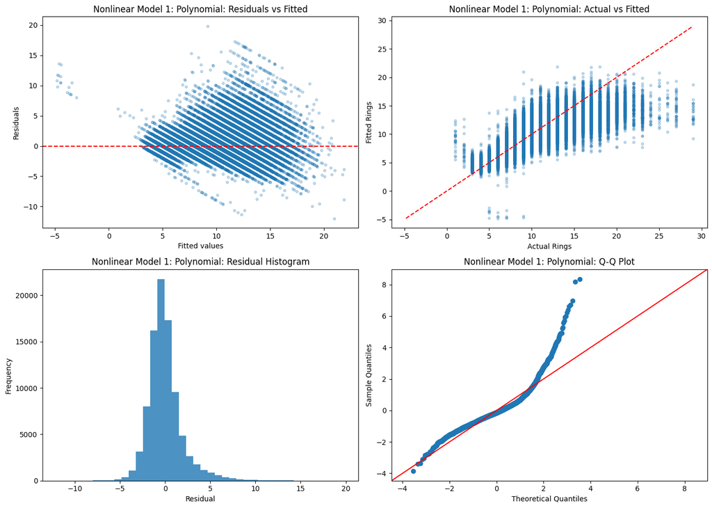

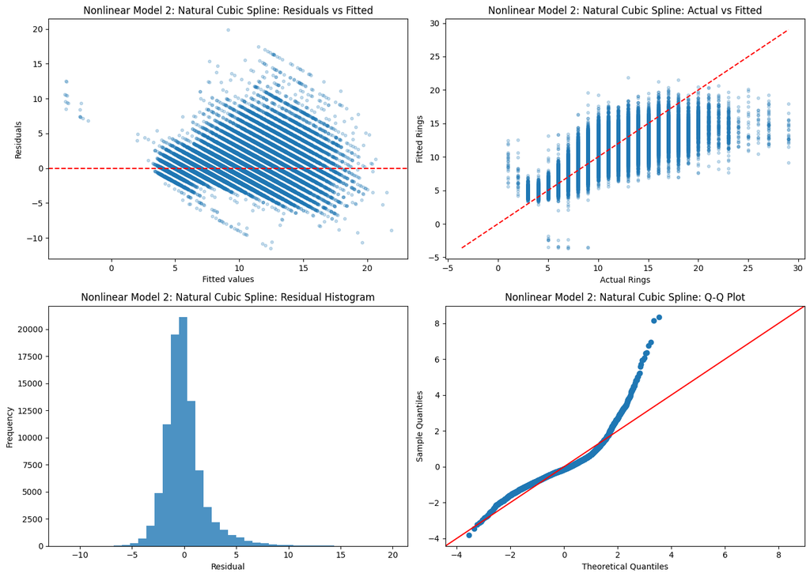

```python
def diagnostic_plots(model, model_name, qq_sample_size=5000):
    fitted = model.fittedvalues
    resid = model.resid

    fig, axes = plt.subplots(2, 2, figsize=(14, 10))

    # Residuals vs fitted
    axes[0, 0].scatter(fitted, resid, alpha=0.25, s=12)
    axes[0, 0].axhline(0, color="red", linestyle="--")
    axes[0, 0].set_title(f"{model_name}: Residuals vs Fitted")
    axes[0, 0].set_xlabel("Fitted values")
    axes[0, 0].set_ylabel("Residuals")

    # Actual vs fitted
    axes[0, 1].scatter(model.model.endog, fitted, alpha=0.25, s=12)
    min_val = min(model.model.endog.min(), fitted.min())
    max_val = max(model.model.endog.max(), fitted.max())
    axes[0, 1].plot([min_val, max_val], [min_val, max_val], color="red", linestyle="--")
    axes[0, 1].set_title(f"{model_name}: Actual vs Fitted")
    axes[0, 1].set_xlabel("Actual Rings")
    axes[0, 1].set_ylabel("Fitted Rings")

    # Histogram of residuals
    axes[1, 0].hist(resid, bins=40, alpha=0.8)
    axes[1, 0].set_title(f"{model_name}: Residual Histogram")
    axes[1, 0].set_xlabel("Residual")
    axes[1, 0].set_ylabel("Frequency")

    # QQ plot using a sample for readability on large data
    qq_resid = resid
    if len(qq_resid) > qq_sample_size:
        qq_resid = qq_resid.sample(qq_sample_size, random_state=42)

    sm.qqplot(qq_resid, line="45", ax=axes[1, 1], fit=True)
    axes[1, 1].set_title(f"{model_name}: Q-Q Plot")

    plt.tight_layout()
    plt.show()

diagnostic_plots(poly_model, "Nonlinear Model 1: Polynomial")
diagnostic_plots(spline_model, "Nonlinear Model 2: Natural Cubic Spline")
```

# Informative nonlinear effect plots

## These help justify the presence of nonlinearity in the data.

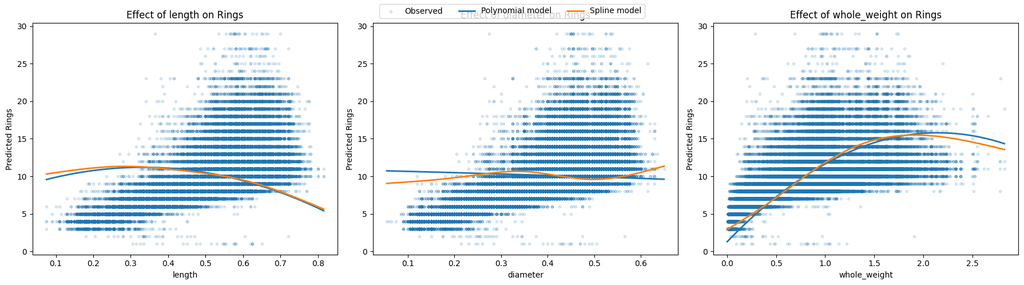

```python
selected_predictors = ["length", "diameter", "whole_weight"]

fig, axes = plt.subplots(1, 3, figsize=(18, 5))

for ax, predictor in zip(axes, selected_predictors):
    pred_df = make_effect_df(train, predictor, n_points=250)

    poly_pred = poly_model.predict(pred_df)
    spline_pred = spline_model.predict(pred_df)

    ax.scatter(train[predictor], train[target_col], alpha=0.15, s=10, label="Observed")
    ax.plot(pred_df[predictor], poly_pred, linewidth=2, label="Polynomial model")
    ax.plot(pred_df[predictor], spline_pred, linewidth=2, label="Spline model")

    ax.set_title(f"Effect of {predictor} on Rings")
    ax.set_xlabel(predictor)
    ax.set_ylabel("Predicted Rings")

handles, labels = axes[0].get_legend_handles_labels()
fig.legend(handles, labels, loc="upper center", ncol=3)
plt.tight_layout()
plt.show()
```

# Choose the best model by CV RMSLE

```python
best_model_name = cv_summary_table.iloc[0]["model"]

if best_model_name == "Baseline Linear":
    best_model = linear_model
    best_formula = linear_formula
elif best_model_name == "Nonlinear Model 1: Polynomial":
    best_model = poly_model
    best_formula = poly_formula
else:
    best_model = spline_model
    best_formula = spline_formula

print("Best model selected by lowest mean CV RMSLE:")
print(best_model_name)
print("\nFormula used:")
print(best_formula)
```

```
Best model selected by lowest mean CV RMSLE:
Nonlinear Model 2: Natural Cubic Spline

Formula used:
rings ~ C(sex) + cr(length, df=5) + cr(diameter, df=5) + cr(height, df=4) + cr(whole_weight, df=5) + cr(whole_weight_1, df=4) + cr(whole_weight_2, df=4) + cr(shell_weight, df=4)
```

# Assignment-ready interpretation text

## This prints direct interpretation sentences for A.2 and A.3.

```python
poly_bp_p = float(poly_diag["breusch_pagan_f_pvalue"].iloc[0])
poly_jb_p = float(poly_diag["jarque_bera_pvalue"].iloc[0])
poly_dw = float(poly_diag["durbin_watson"].iloc[0])

spline_bp_p = float(spline_diag["breusch_pagan_f_pvalue"].iloc[0])
spline_jb_p = float(spline_diag["jarque_bera_pvalue"].iloc[0])
spline_dw = float(spline_diag["durbin_watson"].iloc[0])

print("INTERPRETATION FOR A.1")
print("-" * 60)
print("Two nonlinear models were fitted:")
print("1. An additive polynomial regression model with quadratic terms.")
print("2. An additive natural cubic spline regression model.")
print()
print("The main comparison metric was cross-validated RMSLE because that is aligned with the Kaggle competition metric.")
print(f"The best model by mean CV RMSLE is: {best_model_name}")
print()

print("INTERPRETATION FOR A.2")
print("-" * 60)
print("The coefficient tables above provide the full statistical output for both nonlinear models.")
print("The polynomial model is easier to interpret because each squared term shows whether curvature is present.")
print("The spline model is more flexible, so it is usually interpreted through fitted curves and effect plots instead of single coefficients.")
print("The effect plots above show whether the relationship between Rings and each predictor bends or changes slope.")
print()

print("INTERPRETATION FOR A.3")
print("-" * 60)
print("Polynomial model assumptions:")
print(f"- Homoscedasticity: {interpret_bp(poly_bp_p)} (Breusch-Pagan p-value = {poly_bp_p:.6f})")
print(f"- Normality: {interpret_jb(poly_jb_p)} (Jarque-Bera p-value = {poly_jb_p:.6f})")
print(f"- Independence: {interpret_dw(poly_dw)} (Durbin-Watson = {poly_dw:.4f})")
print()
print("Spline model assumptions:")
print(f"- Homoscedasticity: {interpret_bp(spline_bp_p)} (Breusch-Pagan p-value = {spline_bp_p:.6f})")
print(f"- Normality: {interpret_jb(spline_jb_p)} (Jarque-Bera p-value = {spline_jb_p:.6f})")
print(f"- Independence: {interpret_dw(spline_dw)} (Durbin-Watson = {spline_dw:.4f})")
print()
print("The VIF tables should be used to check multicollinearity.")
print("High VIF values in the spline model are common because spline basis functions are mathematically related.")
print("For the polynomial model, very high VIF values indicate stronger collinearity among the raw and squared terms.")
print()
print("Final modeling conclusion:")
print(f"- Based on the lowest cross-validated RMSLE, the preferred model for Kaggle submission is: {best_model_name}")
```

```
INTERPRETATION FOR A.1
------------------------------------------------------------
Two nonlinear models were fitted:
1. An additive polynomial regression model with quadratic terms.
2. An additive natural cubic spline regression model.

The main comparison metric was cross-validated RMSLE because that is aligned with the Kaggle competition metric.
The best model by mean CV RMSLE is: Nonlinear Model 2: Natural Cubic Spline

INTERPRETATION FOR A.2
------------------------------------------------------------
The coefficient tables above provide the full statistical output for both nonlinear models.
The polynomial model is easier to interpret because each squared term shows whether curvature is present.
The spline model is more flexible, so it is usually interpreted through fitted curves and effect plots instead of single coefficients.
The effect plots above show whether the relationship between Rings and each predictor bends or changes slope.

INTERPRETATION FOR A.3
------------------------------------------------------------
Polynomial model assumptions:
- Homoscedasticity: Evidence of heteroscedasticity (Breusch-Pagan p-value = 0.000000)
- Normality: Residuals depart from normality (Jarque-Bera p-value = 0.000000)
- Independence: No strong evidence of autocorrelation (Durbin-Watson = 2.0022)

Spline model assumptions:
- Homoscedasticity: Evidence of heteroscedasticity (Breusch-Pagan p-value = 0.000000)
- Normality: Residuals depart from normality (Jarque-Bera p-value = 0.000000)
- Independence: No strong evidence of autocorrelation (Durbin-Watson = 2.0013)

The VIF tables should be used to check multicollinearity.
High VIF values in the spline model are common because spline basis functions are mathematically related.
For the polynomial model, very high VIF values indicate stronger collinearity among the raw and squared terms.

Final modeling conclusion:
- Based on the lowest cross-validated RMSLE, the preferred model for Kaggle submission is: Nonlinear Model 2: Natural Cubic Spline
```

# Predict on test data

## Predictions are clipped to the training target range to avoid unreasonable values.

```python
test_predictions = best_model.predict(test)

# Clip predictions to observed training target range
train_min = train[target_col].min()
train_max = train[target_col].max()
test_predictions = np.clip(test_predictions, train_min, train_max)

print("Prediction summary:")
print(pd.Series(test_predictions).describe())
```

```
Prediction summary:
count    60411.000000
mean         9.707532
std          2.524808
min          1.000000
25%          7.913182
50%          9.633793
75%         11.300283
max         21.390293
dtype: float64
```

# Part C: Nonlinear Regression Analysis for the Abalone Rings Prediction Problem

## (b) Interpretation of the Regression Models and Kaggle Submission Evidence

The interpretation of this analysis is pretty straightforward. The polynomial regression model is the easier of the two nonlinear models to interpret. In that model, C(sex)[T.I] had a negative and statistically significant coefficient, which indicates that, holding the other predictors constant, observations in the I category tended to have lower predicted Rings than the reference group. The coefficient for C(sex)[T.M] was not statistically significant, which suggests that after controlling for the other predictors, the distinction between that group and the reference group was weak in this model. The coefficient for I(length²) was negative and significant, which indicates that the effect of length was not simply increasing across the entire range. Instead, the relationship rose and then turned downward, which is consistent with the effect plot (James et al., 2023). The same pattern appeared for height, whole_weight, and shell_weight, where the squared terms were negative and statistically significant. That pattern suggests diminishing returns and curvature rather than a constant linear increase. The model also showed a strong negative linear coefficient for whole_weight_1 and a strong positive squared coefficient for I(whole_weight_12), which indicates a more complex curved response. Some terms, such as diameter, I(diameter2), and I(whole_weight_22), were not statistically significant, meaning their independent contribution was weaker once the other measurements were included. The VIF table showed extremely high multicollinearity for several predictors, especially diameter, length, and their squared terms. This is expected because raw size variables are highly related to one another, and squaring them creates even stronger dependence. As a result, the polynomial model is best interpreted through its overall fitted pattern rather than by treating each coefficient as a clean and isolated effect (Chesnaye et al., 2024). The spline model must be interpreted differently. Its basis coefficients were extremely large and not practically meaningful on their own. That is not unusual for spline basis representations. The spline effect plots showed that whole_weight had the clearest nonlinear association with Rings, with steep gains at lower and middle levels and flattening at the upper end. Length also showed a pronounced bend, while diameter displayed milder curvature. Because the model is additive, each smooth curve can be interpreted as the isolated contribution of one predictor while the others are held fixed. The supplied outputs show that the selected best model was the natural cubic spline model (De Giosa et al., 2025).

## (c) Investigation of Assumptions and Interpretation of Findings

The first assumption issue examined was whether a simple linear structure was adequate. The comparison results strongly suggest that it was not. Both nonlinear models outperformed the baseline linear model on training fit and on cross-validated error. The ANOVA comparison between the linear and polynomial models was highly significant, which confirmed that adding nonlinear terms materially improved the model. The effect plots also showed clear bends in the relationships for length and whole weight. These findings support the conclusion that the linearity assumption was too restrictive for this problem and that nonlinear modeling was justified (Chesnaye et al., 2024). The second assumption issue was homoscedasticity, or constant error variance. Both nonlinear models showed evidence against this assumption. For the polynomial model, the Breusch Pagan F test p-value was 0.0. For the spline model, the Breusch Pagan F test p-value was also 0.0. These results indicate heteroscedasticity in both models. The residual versus fitted plots support the same conclusion. The spread of residuals was not constant across fitted values. The variability widened in some parts of the fitted range and narrowed in others. This means that prediction error changes across the response scale rather than remaining uniform. As a result, the constant variance assumption was violated (Chesnaye et al., 2024). The third assumption issue was residual normality. Once again, both nonlinear models failed this assumption. The Jarque-Bera p-values were 0.0 for both models, which means the residuals departed from normality. The residual histograms were centered near zero, but they were visibly right-skewed and had heavy tails. The QQ plots reinforced this conclusion. In both models, the residuals followed the reference line in the middle only loosely, but they bent away from the line in the tails, especially in the upper tail. That pattern indicates skewness and excess kurtosis. The reported skewness values of 1.521883 for the polynomial model and 1.512829 for the spline model, along with kurtosis values above 9, confirm that the residual distributions were not close to normal (Chesnaye et al., 2024).

The fourth assumption issue was the independence of errors. On this point, the results were favorable. The Durbin Watson statistic was 2.002191 for the polynomial model and 2.001348 for the spline model. Values near 2 suggest no strong evidence of autocorrelation. Therefore, based on the standard interpretation of Durbin-Watson, the independence assumption did not appear to be seriously violated in either nonlinear model (James et al., 2023). Another important issue was multicollinearity. The polynomial model showed extremely large VIF values. Diameter and length had VIF values above 15,000, while several other predictors and squared terms were also very large. This means that the predictors were strongly correlated with one another. In a body measurement dataset, this is not surprising because many size variables reflect overlapping biological dimensions. The spline model also showed huge and even infinite VIF values, but those should be interpreted differently. In spline regression, the basis functions are mathematically related by construction. Therefore, very large VIF values are expected and do not automatically imply that the model is unusable (De Giosa et al., 2025). The nonlinear models successfully addressed the problem of inadequate linearity and improved prediction accuracy. They did not fully satisfy the constant variance and normality assumptions, but they did show acceptable independence of errors. The polynomial model was easier to explain in direct algebraic terms, but it suffered from substantial multicollinearity. The natural cubic spline model was harder to interpret coefficient by coefficient, yet it captured the predictor response shapes more flexibly and produced the best predictive results. For that reason, the spline model is the strongest final choice for the Kaggle competition portion of the assignment (James et al., 2023).

# References

- Chesnaye, N. C., van Diepen, M., Dekker, F., Zoccali, C., Jager, K. J., & Stel, V. S. (2024). Non-linear relationships in Clinical Research. Nephrology Dialysis Transplantation, 40(2), 244–254. https://doi.org/10.1093/ndt/gfae187
- De Giosa, M., Falini, A., Iavernaro, F., Losito, S., Mazzia, F., & Rubino, G. (2025). A robust variant of cubic smoothing spline approximation. Numerical Algorithms, 101(1), 221–241. https://doi.org/10.1007/s11075-024-02003-7
- James, G., Witten, D., Hastie, T., Tibshirani, R., & Taylor, J. (2023). An introduction to statistical learning with applications in Python. Springer Nature.
- Lin, Y.-S., Fan, C.-P., Lee, M.-Y., & Lee, Y.-H. (2026). Mathematical computation of piecewise linear regression with endogenous segmentation for accurate data-based Model Building: An example of the Phillips curve. Mathematics, 14(6), 1041. https://doi.org/10.3390/math14061041